# Measuring Decline

# Data

All data used is reported annually at the county-level. Therefore, no time-invariant variables are included (apart from the State in which a county is in, which is made time-variant through the inclusion of a state-level trend in various models).

**GDP Controls:** US Bureau of Economic Analysis. Values are also reported in current US dollars (real GDP values exist). The controls used in the below are total, private industry, and oil, gas, mining & quarrying county-level GDP.

**Population controls:** US Census Bureau.

**Coal mine activity and production levels:** Mine Safety and Health Administration

# Defining Decline

What would be great is to be able to econometrically test when a county is “declining.” In the first step, it would be good to identify when a county is declining overall (GDP, poverty, etc) but ideally eventually apply this to the education outcome. My hope is that being able to identify counties that are “declining” we can either use this variable as a covariate or as a central point of analysis. The below analysis looks at state-level variables as a first step (mainly to aid in visual comparison and plotting). Ideally, once a method is decided on this would be applied to county-level data which would need to be summarise/collated in some useful way for plotting.

Below I suggest a few options (some of which I have tried). They require functions and tests from time series literature and it would be great to get Jennie’s input/direction on this.

## First step (GDP only):

- Negative trend (X)
- Autocorrelation (X) – If autocorrelation is consistently positive indicates trend? – Should this focus on autocorrelation in levels or differences?
- Trend indicator saturation - negative trend breaks? (_)
- Exhibit national or state-level GDP growth as global common factor; counties with negative factor loadings might arguably exhibit decline (_)

### Negative trend

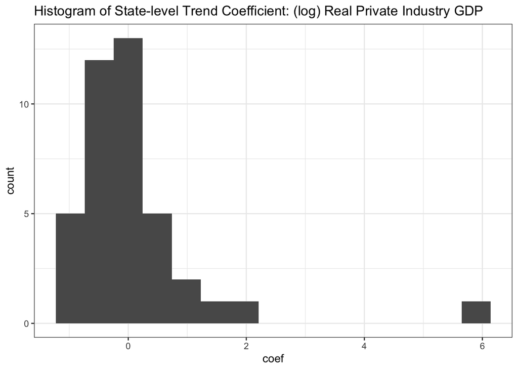

```r
trends <- feols(log_real_gdp_priv_ind ~ time:as.factor(state) | state + year, data = state_lev, se = "cluster", cluster = "state", panel.id = ~state+year)

#trends %>% etable(., se.below = TRUE)

trends$coefficients %>%
  tibble %>%
  rename(coef = '.') %>%
  ggplot() +
  geom_histogram(aes(x = coef), bins = 15) +
  theme_bw() +
  labs(title = "Histogram of State-level Trend Coefficient: (log) Real Private Industry GDP")
```

### Autocorrelation

Levels

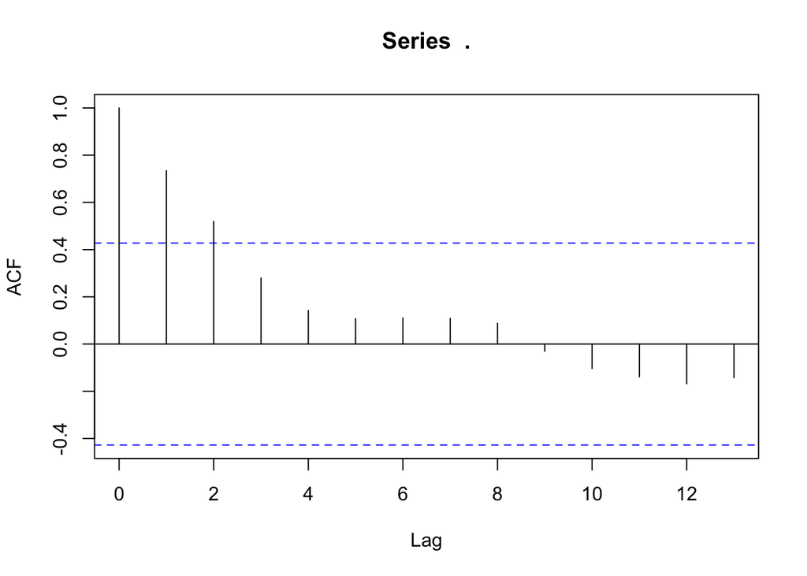

```r
state_list <- unique(state_lev$state)

acf_list <- list()
for(s in 1:length(state_list)){
  ps <- state_lev %>%
    filter(state == state_list[s]) %>%
    pull(real_gdp_priv_ind) %>%
    acf(., na.action = na.pass, plot = FALSE)

  acf_list[[s]] <- ps
}

acf_list[[1]] %>% plot
```

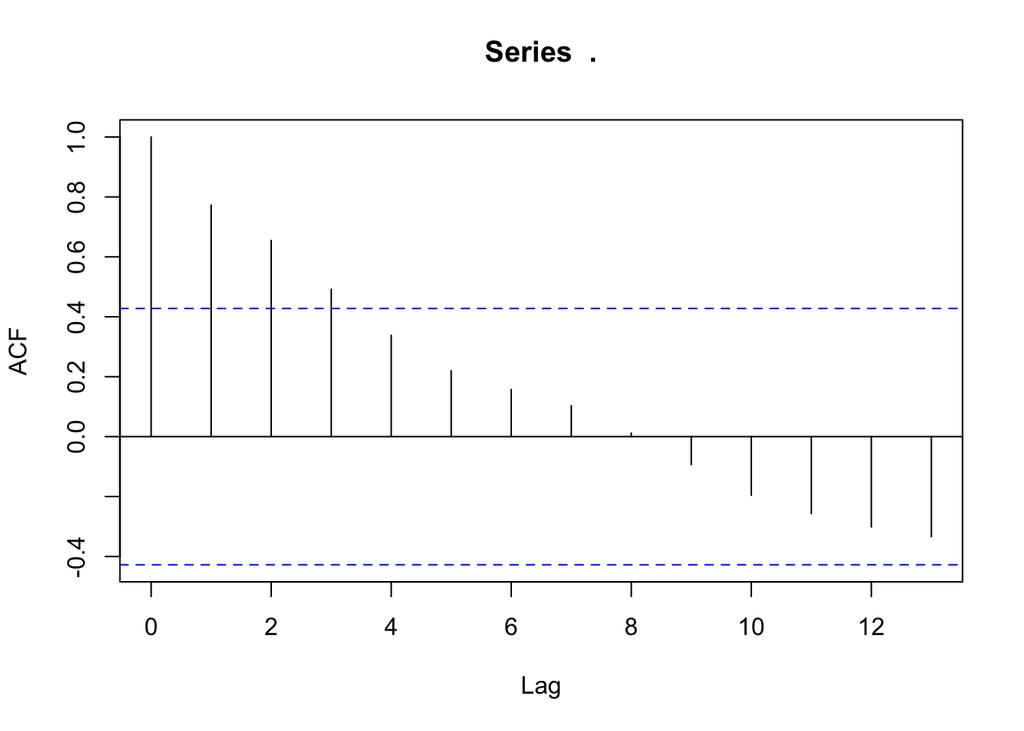

```r
acf_list[[10]] %>% plot
```

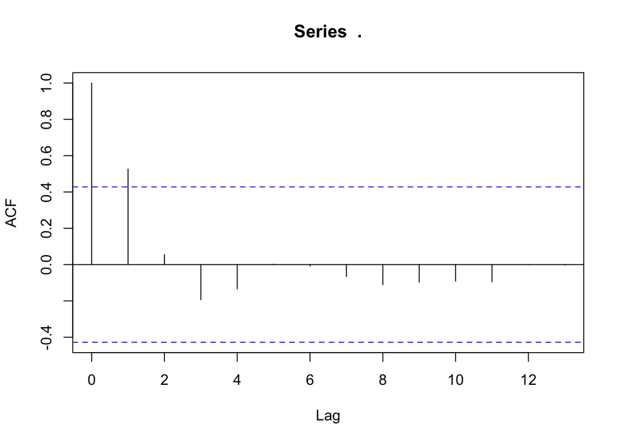

```r
acf_list[[15]] %>% plot
```

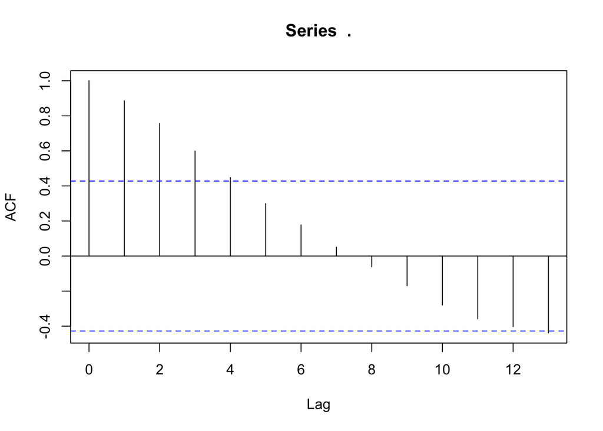

```r
acf_list[[30]] %>% plot
```

## Second step (Education):

- Autocorrelation (Education only) (X)
- Correlation plots (X)
- Cross-correlation plot of Education and GDP (X)
- Are GDP and Education Expenditure cointegrating (or do they exhibit a decoupling?) (_)

### Autocorrelation

Levels

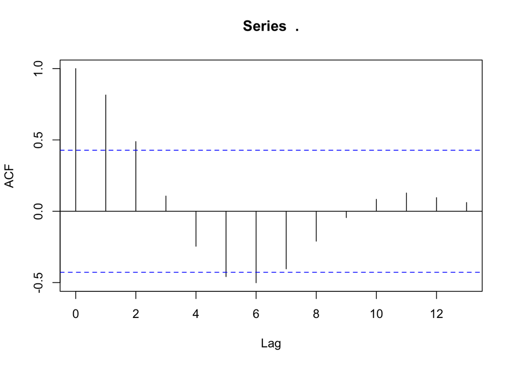

```r
state_list <- unique(state_lev$state)

acf_list <- list()
for(s in 1:length(state_list)){
  ps <- state_lev %>%
    filter(state == state_list[s]) %>%
    pull(real_Elem_Educ_Total_Exp) %>%
    acf(., na.action = na.pass, plot = FALSE)

  acf_list[[s]] <- ps
}

acf_list[[1]] %>% plot
```

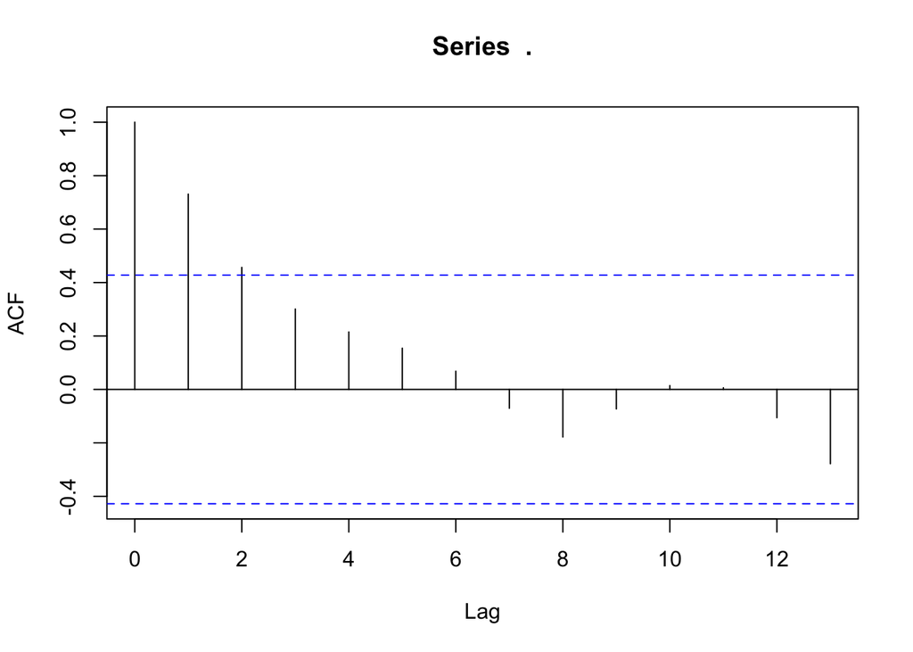

```r
acf_list[[10]] %>% plot
```

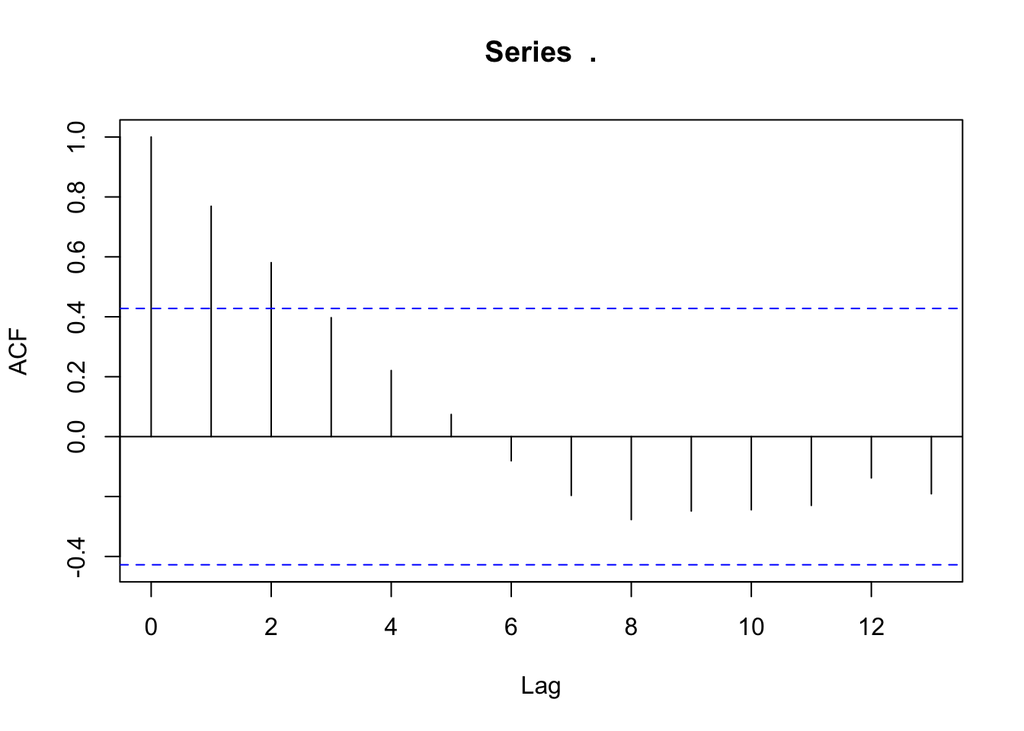

```r
acf_list[[15]] %>% plot
```

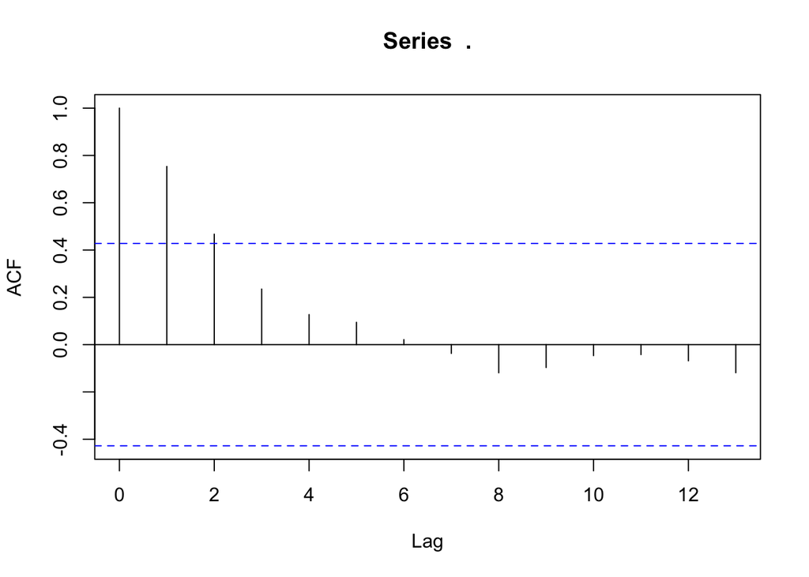

```r
acf_list[[30]] %>% plot
```

### Correlation Plots (Education and GDP)

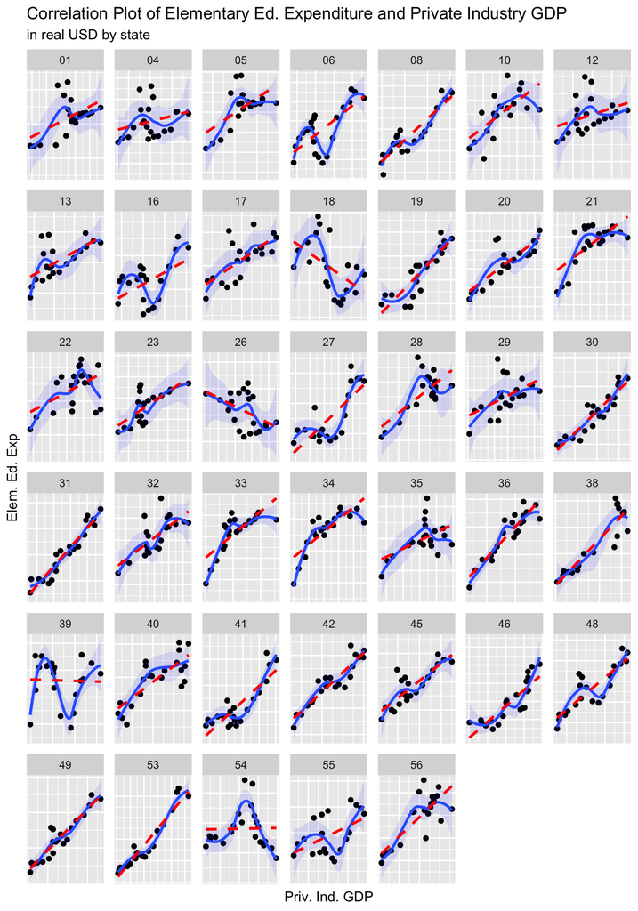

```r
ggplot(state_lev,
       aes(x= real_gdp_priv_ind,
           y= real_Elem_Educ_Total_Exp))+
  geom_point()+
  facet_wrap(~state, scales = "free") +
  geom_smooth(fill="blue", alpha=0.1)+
  geom_smooth(method='lm', formula= y~x, se=FALSE, col="red",lty=2)+
  theme(axis.text.y = element_blank(),
        axis.ticks.y = element_blank(),
        axis.text.x = element_blank(),
        axis.ticks.x = element_blank())+
    labs(title = "Correlation Plot of Elementary Ed. Expenditure and Private Industry GDP",
       subtitle = "in real USD by state",
       y = "Elem. Ed. Exp",
       x = "Priv. Ind. GDP")
```

### Cross-correlation of Educ Exp and Priv. Industry GDP

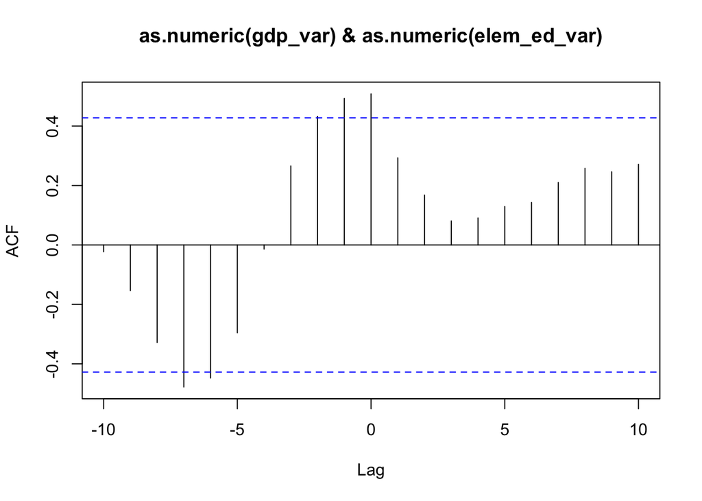

```
Autocorrelations of series 'X', by lag

   -10     -9     -8     -7     -6     -5     -4     -3     -2     -1      0
-0.023 -0.154 -0.328 -0.478 -0.448 -0.295 -0.014  0.266  0.433  0.493  0.508
     1      2      3      4      5      6      7      8      9     10
 0.293  0.168  0.081  0.091  0.129  0.143  0.210  0.258  0.246  0.272
```

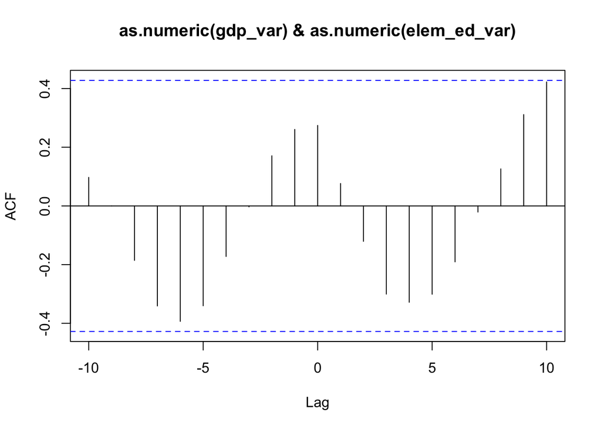

```
Autocorrelations of series 'X', by lag

   -10     -9     -8     -7     -6     -5     -4     -3     -2     -1      0
 0.097  0.000 -0.186 -0.341 -0.393 -0.340 -0.172 -0.003  0.171  0.261  0.274
     1      2      3      4      5      6      7      8      9     10
 0.076 -0.121 -0.300 -0.328 -0.301 -0.191 -0.021  0.126  0.311  0.422
```

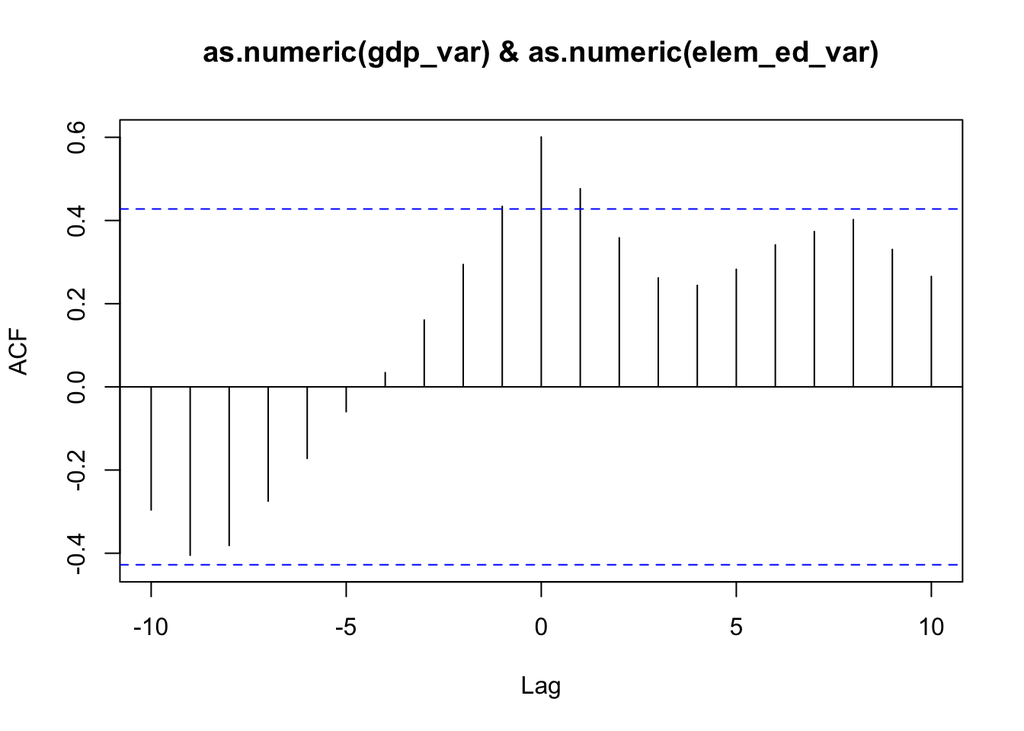

```
Autocorrelations of series 'X', by lag

   -10     -9     -8     -7     -6     -5     -4     -3     -2     -1      0
-0.296 -0.405 -0.381 -0.275 -0.172 -0.060  0.034  0.161  0.294  0.434  0.601
     1      2      3      4      5      6      7      8      9     10
 0.476  0.359  0.262  0.244  0.283  0.341  0.374  0.402  0.330  0.265
```

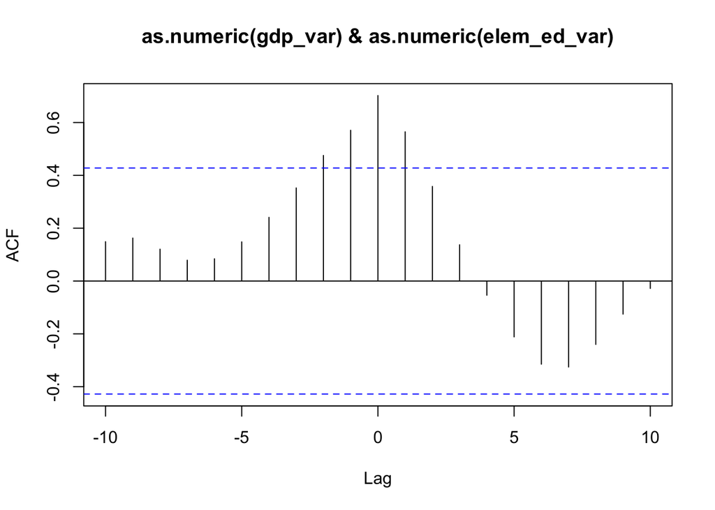

```
Autocorrelations of series 'X', by lag

   -10     -9     -8     -7     -6     -5     -4     -3     -2     -1      0
 0.149  0.163  0.120  0.079  0.084  0.148  0.241  0.352  0.475  0.571  0.702
     1      2      3      4      5      6      7      8      9     10
 0.565  0.358  0.137 -0.054 -0.211 -0.315 -0.325 -0.240 -0.125 -0.028
```

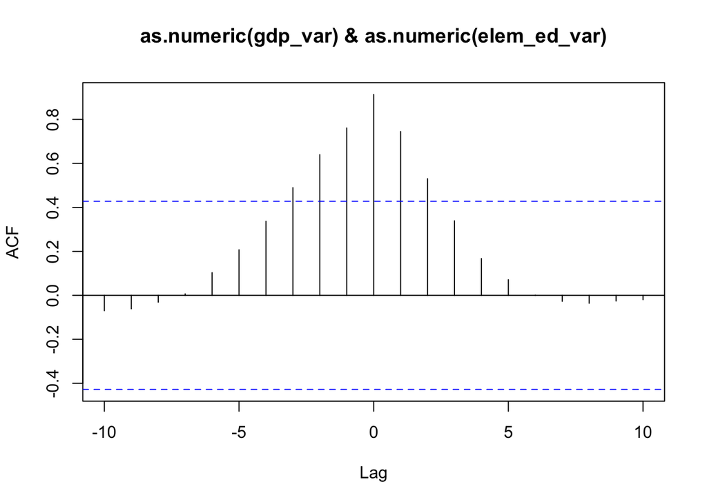

```
Autocorrelations of series 'X', by lag

   -10     -9     -8     -7     -6     -5     -4     -3     -2     -1      0
-0.070 -0.061 -0.031  0.007  0.103  0.207  0.337  0.490  0.640  0.761  0.914
     1      2      3      4      5      6      7      8      9     10
 0.745  0.531  0.339  0.167  0.071  0.001 -0.027 -0.036 -0.026 -0.020
```

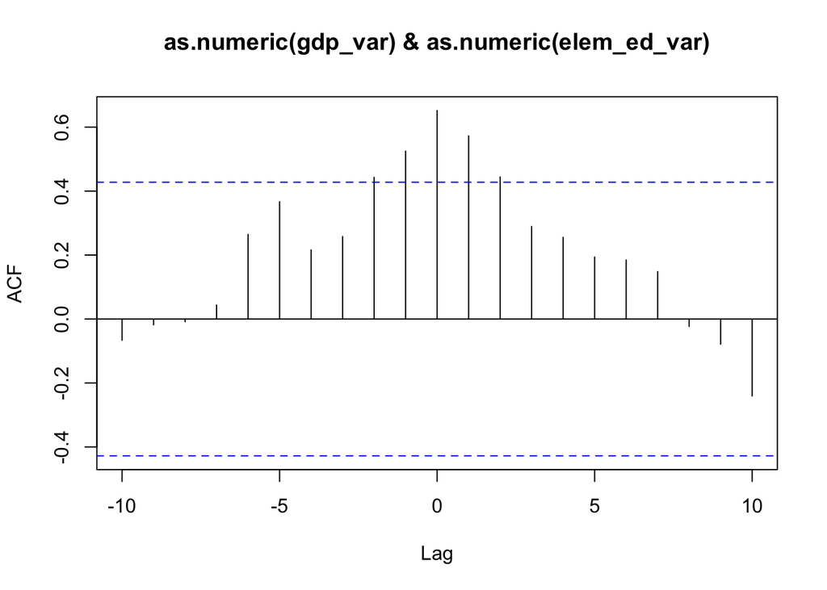

```
Autocorrelations of series 'X', by lag

   -10     -9     -8     -7     -6     -5     -4     -3     -2     -1      0
-0.066 -0.018 -0.008  0.044  0.264  0.367  0.216  0.258  0.443  0.525  0.652
     1      2      3      4      5      6      7      8      9     10
 0.572  0.444  0.289  0.255  0.194  0.185  0.148 -0.023 -0.079 -0.241
```

```r
for(s in 1:length(state_list[1:6])){

  gdp_var <- state_lev %>%
    filter(state == state_list[s]) %>%
    pull(real_gdp_priv_ind)

  elem_ed_var <- state_lev %>%
    filter(state == state_list[s]) %>%
    pull(real_Elem_Educ_Total_Exp)

  cor(gdp_var, elem_ed_var)
  ccf(as.numeric(gdp_var), as.numeric(elem_ed_var)) %>% print
}
```

```r
#aTSA::coint.test(Deathts, VAXts, d = 1, nlag = 2, output = TRUE)
```

### Evidence of decoupling

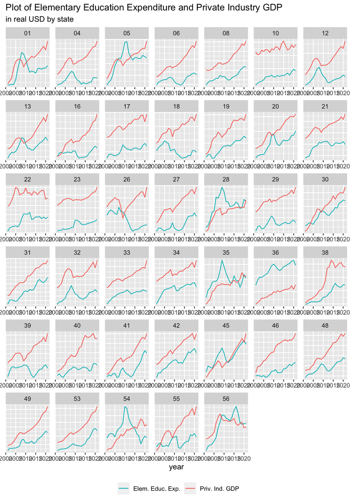

```r
ggplot(state_lev,
       aes(x= year))+
  geom_line(aes(y = real_Elem_Educ_Total_Exp, colour = 'red'))+
  geom_line(aes(y= real_gdp_priv_ind/20, colour = 'blue')) +
  facet_wrap(~state, scales = "free") +
  scale_color_discrete(name="",
                         breaks=c("red", "blue"),
                        labels = c("Elem. Educ. Exp.", "Priv. Ind. GDP")) +
  theme(axis.text.y = element_blank(),
        axis.ticks.y = element_blank(),
        legend.position = "bottom") +
  labs(title = "Plot of Elementary Education Expenditure and Private Industry GDP",
       subtitle = "in real USD by state",
       y = NULL)
```